# Self-Driving Car Engineer Nanodegree

## Project: Build a Traffic Sign Recognition Classifier

### Ajay Paidi

```python
import tensorflow as tf
from sklearn.utils import shuffle
from tensorflow.contrib.layers import flatten
from sklearn.model_selection import train_test_split
import pickle
import matplotlib.pyplot as plt
import numpy as np
# Visualizations will be shown in the notebook.
#plt.style.use('ggplot')
plt.style.use('seaborn-notebook')
%matplotlib inline
# see http://stackoverflow.com/questions/1907993/autoreload-of-modules-in-ipython
%load_ext autoreload
%autoreload 2
import trHelper as helper
import preprocess_data as preprocess
import time
```

```python
# Load pickled data
# Note: The original pickled data was pre-processed to produce another pickle file, which is loaded below
# The pre-processing involved data augmentation (please see the attached script augment_data.py )
# The augmented data was then histogram equalized (please see the attached script hist_eq_images.py)

training_file = "../data/traffic-signs-data/train_aug_hist_eq.p"
validation_file = "../data/traffic-signs-data/valid_aug_hist_eq.p"
testing_file = "../data/traffic-signs-data/test_hist_eq.p"

with open(training_file, mode='rb') as f:
    train = pickle.load(f)
with open(validation_file, mode='rb') as f:
    valid = pickle.load(f)
with open(testing_file, mode='rb') as f:
    test = pickle.load(f)

X_train, y_train = train['features'], train['labels']
X_valid, y_valid = valid['features'], valid['labels']
X_test, y_test = test['features'], test['labels']

# print dims
print("X_train, y_train shape",X_train.shape, y_train.shape)
print("X_valid, y_valid shape",X_valid.shape, y_valid.shape)
print("Number of y_train labels, y_valid labels",len(set(y_train)), len(set(y_valid)))
```

```
X_train, y_train shape (35300, 32, 32, 3) (35300,)
X_valid, y_valid shape (7842, 32, 32, 3) (7842,)
Number of y_train labels, y_valid labels 43 43
```

## Step 1: Dataset Summary & Exploration

```python
# TODO: Number of training examples
n_train = X_train.shape[0]
n_valid = X_valid.shape[0]

# TODO: Number of testing examples.
n_test = X_test.shape[0]

# TODO: What's the shape of an traffic sign image?
image_shape = X_train.shape[1:]

# TODO: How many unique classes/labels there are in the dataset.
n_classes = len(set(y_train))

print("Number of training examples =", n_train)
print("Number of validation examples =", n_valid)
print("Number of testing examples =", n_test)
print("Image data shape =", image_shape)
print("Number of classes =", n_classes)
print("min label, max label", np.min(y_train), np.max(y_train))
```

```
Number of training examples = 35300
Number of validation examples = 7842
Number of testing examples = 12630
Image data shape = (32, 32, 3)
Number of classes = 43
min label, max label 0 42
```

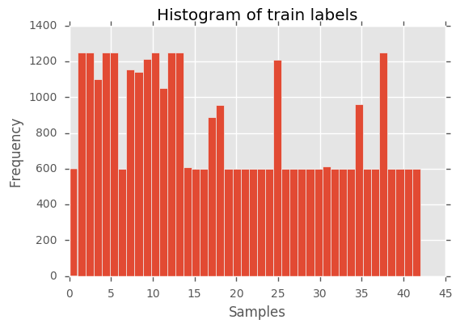

```python
# checkout the distribution of train labels
with plt.style.context('ggplot'):
    plt.figure()
    plt.hist(y_train, n_classes)
    plt.xlabel('Samples')
    plt.ylabel('Frequency')
    plt.title('Histogram of train labels')
```

```python
# similarly have a peek at the test label distribution
# plt.figure()
# plt.hist(y_test, n_classes)
# plt.xlabel('Samples')
# plt.ylabel('Frequency')
```

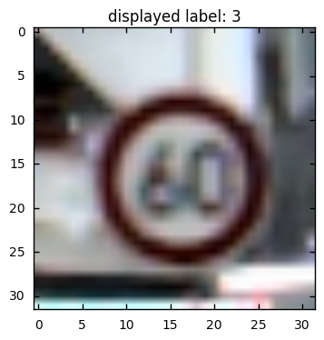

```python
# Run this cell several times to get an idea of how the images look like
def display_random_image(n_samples, X, y):
    index = np.random.randint(n_samples)
    img = X[index,...]
    lbl = y[index]
    plt.figure()
    with plt.style.context('seaborn-notebook'):
        plt.imshow(img.astype(np.uint8))
        plt.title("displayed label: " + str(lbl))
display_random_image(n_train, X_train, y_train)
```

## Preprocess

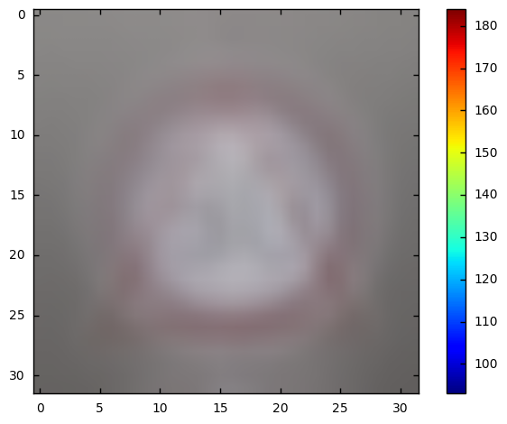

```python
# note: images have already been histogram equalized
# Convert features to float32 and shape into desired tensor flow format
X_train = np.array(X_train, dtype='float32')
X_valid = np.array(X_valid, dtype='float32')
X_test = np.array(X_test, dtype='float32')

mean_img = preprocess.compute_train_mean(X_train)
with plt.style.context('seaborn-notebook'):
    plt.figure()
    plt.imshow(mean_img.astype(np.uint8))
    plt.colorbar()
```

```python
# Subtract mean - This has the effect of zero centering the data for good optimization
X_train = preprocess.subtract_mean(X_train, mean_img)
X_valid = preprocess.subtract_mean(X_valid, mean_img)
X_test = preprocess.subtract_mean(X_test, mean_img)
#display_random_image(n_train, X_train, y_train)
# Perform min-max scaling - This keeps the values of the input small enough for good optimization
train_min, train_max = preprocess.compute_train_statistics(X_train)
print("Min and max train pixel values", train_min, train_max)
X_train = preprocess.min_max_scaling(X_train, train_min, train_max)
X_valid = preprocess.min_max_scaling(X_valid, train_min, train_max)
X_test = preprocess.min_max_scaling(X_test, train_min, train_max)

print("X_train shape, X valid  shape, X_test shape", X_train.shape, X_valid.shape, X_test.shape)
print("Min and max X_train", np.min(X_train), np.max(X_train))
```

```
Min and max train pixel values -184.145 161.151
X_train shape, X valid  shape, X_test shape (35300, 32, 32, 3) (7842, 32, 32, 3) (12630, 32, 32, 3)
Min and max X_train -1.0 1.0
```

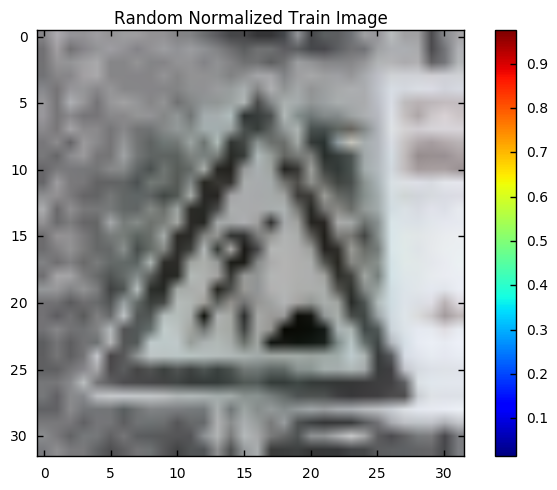

```python
#show the normalized image
index = np.random.randint(n_train)
tmp = X_train[index,...]
# imshow expects float values to be in range 0.0 to 1.0 - hence add 1 and divide by 2
with plt.style.context('seaborn-notebook'):
    plt.figure()
    plt.imshow((tmp + 1.0)/2.0)
    plt.colorbar()
    plt.title('Random Normalized Train Image')
```

### Question 1

*Describe how you preprocessed the data. Why did you choose that technique?*

I did the following pre-processing steps

1. Mean subtraction: This is the most common and obvious pre-processing step. I took the mean across all the samples of the training data and computed a 'training mean image'. I then subtracted this image from the training, validation and test data. This has the effect of centering the data around the origin (for every dimension of the feature vector) and thus making it more suitable for optimization.
2. Min max scaling: I initially did not bother with normalization (i.e dividing with standard deviation) because these are 8 bit images (pixel values 0-255). Normalizing typically makes sense if different features are of different scales. But here all the feature values have the same scale (0-255). However I noticed that my model was taking more epochs to converge to the minimum (> 50 epochs). After min max scaling the inputs (min val -1.0 and max val 1.0), I was achieving the same results in about 10 epochs.
3. Histogram Equalization: From a general look at the training dataset, the images are taken under very varied lighting conditions. Performing a histogram equalization helps to balance the distribution of pixels in an image and thus alleviate the effects of increased or decreased lighting. In practice doing an histogram equalization allowed me to get a 1-2% boost in my final test accuracy result. Please note that I first did the histogram equalization on the raw input pickled data before doing the other pre-processing operations.

### Question 2

*Describe how you set up the training, validation and testing data for your model. **Optional**: If you generated additional data, how did you generate the data? Why did you generate the data? What are the differences in the new dataset (with generated data) from the original dataset?*

# Data augmentation:

1. Rotation:-10 degrees to 10 degrees
2. Translation: - 6mm to 6mm in x and y directions
3. Scale: 0.9 to 1.1 zoom factors
4. Shear: -4 degress to 4 degrees
5. I also added random Gaussian noise to approximately 1/3 of the augmented images.

# Train / Validation/ Testing split:

I used the sklearn module to split the training data into 80% training set and 20% validation set. I preserved the given test data as it is.

Note: During initial training, I obtained the biggest boost in my testing accuracy only after data augmentation. My initial testing accuracy hovered around 70-75%. Data augmentation boosted that number to about 91%.

```python
# start tf graph
# Convert data to tensor flow format
X_tf = tf.placeholder(tf.float32, [None, image_shape[0], image_shape[1], image_shape[2]])
y_tf = tf.placeholder(tf.int32, [None])
y_one_hot = tf.one_hot(y_tf, n_classes)

print("X_tf, y_tf, y_one_hot", X_tf.get_shape(), y_tf.get_shape(), y_one_hot.get_shape())
```

```
X_tf, y_tf, y_one_hot (?, 32, 32, 3) (?,) (?, 43)
```

```python
# cache the weights in a dict - useful for regularization
weights = {'W1':[], 'W2':[], 'W3':[], 'W4':[], 'W5':[], 'w6':[], 'W7':[]}
batch_norm = True

keep_prob = tf.placeholder(tf.float32)
dp_dict = {'do_dropout': True, 'keep_prob': keep_prob}

# conv layer 1
h1, W1 = helper.conv2d(X_tf, 32, 5, 5, 1, 1, padding = 'SAME', name = 'conv1', activation = tf.nn.relu, \
                      dropout_dict = dp_dict)
weights['W1'] = W1
pool1 = helper.maxPool2d(h1, name = 'pool1')

if batch_norm:
    pool1 = tf.nn.local_response_normalization(pool1)

# Convolution Layer 2.
h2, W2 = helper.conv2d(pool1, 64, 5, 5, 1, 1, padding = 'SAME', name = 'conv2', activation = tf.nn.relu,\
                       dropout_dict = dp_dict)
weights['W2'] = W2
#pool2 = helper.maxPool2d(h2, name = 'pool2')

if batch_norm:
    pool2 = tf.nn.local_response_normalization(h2)

# Convolution Layer 3.
h3, W3 = helper.conv2d(pool2, 128, 5, 5, 1, 1, padding = 'SAME', name = 'conv3', activation = tf.nn.relu,\
                       dropout_dict = dp_dict)
weights['W3'] = W3
#pool3 = helper.maxPool2d(h3, name = 'pool3')

if batch_norm:
    pool3 = tf.nn.local_response_normalization(h3)

#fc layer 1
n_hidden = 1024
h4, W4 = helper.fc_layer(pool3, n_hidden, name = 'fc1', activation = tf.nn.relu, dropout_dict = dp_dict)
weights['W4'] = W4
if batch_norm:
    tmp4 = tf.reshape(h4, [-1, 512, 512, 1] )
    tmp4 = tf.nn.local_response_normalization(tmp4)
    h4 = flatten(h4)

#fc layer 2
h5, W5 = helper.fc_layer(h4, n_hidden, name = 'fc2', activation = tf.nn.relu, dropout_dict = dp_dict)
weights['W5'] = W5
if batch_norm:
    tmp5 = tf.reshape(h5, [-1, 512, 512, 1] )
    tmp5 = tf.nn.local_response_normalization(tmp5)
    h5 = flatten(h5)

#fc layer 3
logits, W6 = helper.fc_layer(h5, n_classes, name = 'fc3')
weights['W6'] = W6
```

```
applying dropout
applying dropout
applying dropout
applying dropout
applying dropout
```

```python
#tf.reset_default_graph()
```

```python
#regularize
#reg = 0.1
# W1, W2, W3, W4, W5 = weights['W1'], weights['W2'], weights['W3'], weights['W4'], weights['W5']
# reg_list = [tf.reduce_sum(tf.mul(W1,W1)), tf.reduce_sum(tf.mul(W2,W2)), tf.reduce_sum(tf.mul(W3,W3)),\
#             tf.reduce_sum(tf.mul(W4,W4)), tf.reduce_sum(tf.mul(W5,W5))]
# reg_loss = 0.5*reg*tf.add_n(reg_list)

learning_rate = 0.001
loss_operation = tf.reduce_mean(tf.nn.softmax_cross_entropy_with_logits(logits, y_one_hot)) #+ reg_loss

optimizer = tf.train.AdamOptimizer(learning_rate)
training_operation = optimizer.minimize(loss_operation)
correct_prediction = tf.equal(tf.argmax(logits, 1), tf.argmax(y_one_hot, 1))
accuracy_operation = tf.reduce_mean(tf.cast(correct_prediction, tf.float32))
pred_op = tf.argmax(logits, 1)
```

# Model Evaluation

```python
# model evaluation (on validation data)
batch_size = 500
def evaluate(X_data, y_data, sess):
    num_examples = len(X_data)
    #print("num examples and batch size - must be same", num_examples, batch_size)
    total_accuracy, total_loss = 0, 0
    #sess = tf.get_default_session()
    for offset in range(0, num_examples, batch_size):
        batch_x, batch_y = X_data[offset:offset+batch_size], y_data[offset:offset+batch_size]
        loss, accuracy =  sess.run([loss_operation, accuracy_operation], feed_dict={X_tf: batch_x, y_tf: batch_y,\
                                                                                    keep_prob: 1.0})
        total_accuracy += (accuracy * batch_x.shape[0])
        total_loss     += (loss * batch_x.shape[0])
    return total_loss / num_examples, total_accuracy / num_examples
```

# Model Training

```python
n_epochs = 30#20
sess = tf.Session()
# train the model
sess.run(tf.global_variables_initializer())
#sess.run(tf.initialize_all_variables())
num_examples = len(X_train)

print("Training...")
print()
start_time = time.time()
# keep track of training and validation loss and accuracies
# this is useful for plotting learning curves
train_loss_vec = []
train_acc_vec = []
val_loss_vec = []
val_acc_vec = []
train_loss, train_accuracy = 0.0, 0.0
for i in range(n_epochs):
    print("EPOCH {} ...".format(i+1))
    X_train, y_train = shuffle(X_train, y_train)
    for offset in range(0, num_examples, batch_size):
        end = offset + batch_size
        batch_x, batch_y = X_train[offset:end], y_train[offset:end]
        loss = sess.run(training_operation, feed_dict={X_tf: batch_x, y_tf: batch_y, keep_prob: 0.35})
    # train acc
    # compute training accuracy just for the last epoch
    if i == n_epochs - 1:
        train_loss, train_accuracy = evaluate(X_train, y_train, sess)
        print("Train Loss     = {:.3f}".format(train_loss))
        print("Train Accuracy     = {:.3f}".format(train_accuracy))
    #validation
    X_valid, y_valid = shuffle(X_valid, y_valid)
    validation_loss, validation_accuracy = evaluate(X_valid, y_valid, sess)
    #stuff for plotting
    #train_loss_vec.append(train_loss)
    #train_acc_vec.append(train_accuracy)
    val_loss_vec.append(validation_loss)
    val_acc_vec.append(validation_accuracy)
    print("Validation Loss     = {:.3f}".format(validation_loss))
    print("Validation Accuracy = {:.3f}".format(validation_accuracy))
    print()
end_time = time.time()
print("time taken to train is", end_time - start_time," seconds")
test_loss, test_accuracy = evaluate(X_test, y_test, sess)
print("Test Loss     = {:.3f}".format(test_loss))
print("Test Accuracy     = {:.3f}".format(test_accuracy))

#pred_y = tf.argmax((logits), feed_dict={X_tf: X_data})
```

```
Training...

EPOCH 1 ...
Validation Loss     = 2.143
Validation Accuracy = 0.363

EPOCH 2 ...
Validation Loss     = 1.035
Validation Accuracy = 0.656

EPOCH 3 ...
Validation Loss     = 0.527
Validation Accuracy = 0.827

EPOCH 4 ...
Validation Loss     = 0.367
Validation Accuracy = 0.880

EPOCH 5 ...
Validation Loss     = 0.240
Validation Accuracy = 0.925

EPOCH 6 ...
Validation Loss     = 0.240
Validation Accuracy = 0.920

EPOCH 7 ...
Validation Loss     = 0.145
Validation Accuracy = 0.953

EPOCH 8 ...
Validation Loss     = 0.153
Validation Accuracy = 0.952

EPOCH 9 ...
Validation Loss     = 0.117
Validation Accuracy = 0.964

EPOCH 10 ...
Validation Loss     = 0.100
```

[output cut: 72 more lines]

```
Validation Accuracy = 0.989

EPOCH 29 ...
Validation Loss     = 0.048
Validation Accuracy = 0.985

EPOCH 30 ...
Train Loss     = 0.017
Train Accuracy     = 0.995
Validation Loss     = 0.036
Validation Accuracy = 0.989

time taken to train is 1586.4356179237366  seconds
Test Loss     = 0.231
Test Accuracy     = 0.950
```

```python
# save model
saver = tf.train.Saver()
save_path = saver.save(sess, "models/model.ckpt")
print("Model saved in file: %s" % save_path)
```

```
Model saved in file: models/model.ckpt
```

Question 3 _What does your final architecture look like? (Type of model, layers, sizes, connectivity, etc.)

### Question 4

*How did you train your model? (Type of optimizer, batch size, epochs, hyperparameters, etc.)*

Please note: I intentionally did not perform hyper parameter training for 2 reasons

1. I was limited by the hardware choices at my disposal.
2. Individually playing with different parameters allowed me to gain a deeper understanding of my model and deep learning in general.

### Question 5

*What approach did you take in coming up with a solution to this problem? It may have been a process of trial and error, in which case, outline the steps you took to get to the final solution and why you chose those steps. Perhaps your solution involved an already well known implementation or architecture. In this case, discuss why you think this is suitable for the current problem.*

I started with the leNet architecture as shown in the lessons and slowly started improvising on it. Please look at the attached document (TrafficSignsResults.pdf) where I have documented my different trials and accuracies.

Some general observations / lessons learnt

1. Initializing the weights correctly is expremely important. The weight scale parameter (if you are not using Xavier initialization or some similar automated weight scaler) is probably as important a hyper parameter as the learning rate for the optimizer.
2. Data augmentation provided the biggest boost in my test accuracies. I believe I could explore some smarter strategies to perform data augmentation to achieve even higher test accuracies than the 95% currently attained by my model.
3. Dropouts were highly effective in preventing overfitting.
4. It generally helps to keep the values of your features (and weights) small. Optimizers in general do not seem to like large values. So scaling down the inputs is quite important. Also batch normalization is your friend especially if you have a very big network with lots of layers.
5. My test accuracies were consistently 4-6% lower than my validation accuracies. This troubled me a lot. This cannot be attributed to overfitting. I took great care in ensuring that my validation set is quite 'pristine'. I used it only to print out the accuracies during training. I never used it for hyper parameter training either. My final conclusion on this is that the distribution of labels in the given train data set (and I maintain the same distribution for my validation set) is quite different from the distribution of the test data set (which I verified by plotting the distributions of the train and test datasets). One could easily overcome this by changing the distribution of the validation set to match the test set. But that would be cheating since in real world scenarios one would never be given the test labels.

# Apply saved model

```python
# retrieve model
# sess = tf.Session()
# saver = tf.train.Saver()
# saver.restore(sess, "models/amazon_lr0.001_nepochs30/model.ckpt")
# print("Model restored.")
# print("logits shape", logits.get_shape())
```

[output not shown]

```python
pred_op = tf.argmax(logits, 1)
y_pred = sess.run(pred_op, feed_dict = {X_tf: X_test, keep_prob: 1.0})
print("y_pred, y_test shape", y_pred.shape, y_test.shape)
```

```
y_pred, y_test shape (12630,) (12630,)
```

```python
from sklearn.metrics import confusion_matrix
cm = confusion_matrix(y_test, y_pred)
```

[output not shown]

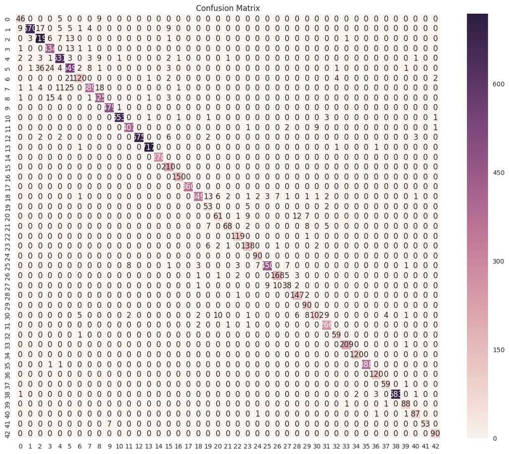

```python
# let us visualize the confusion matrix
print(cm.shape)
#https://stackoverflow.com/questions/35572000/how-can-i-plot-a-confusion-matrix
import seaborn as sn
import pandas as pd
df_cm = pd.DataFrame(cm)
with plt.style.context('seaborn-notebook'):
    plt.figure(figsize = (15,12))
    sn.heatmap(df_cm, linewidths=0.5, annot=True, fmt='g')
    plt.title('Confusion Matrix')
```

```python
from sklearn import metrics
f1_report = metrics.classification_report(y_test, y_pred)
print("Classification report %s\n" % f1_report)
```

```
Classification report              precision    recall  f1-score   support

          0       0.75      0.77      0.76        60
          1       0.99      0.93      0.96       720
          2       0.92      0.96      0.94       750
          3       0.90      0.96      0.93       450
          4       0.94      0.96      0.95       660
          5       0.87      0.87      0.87       630
          6       0.91      0.80      0.85       150
          7       0.96      0.86      0.91       450
          8       0.92      0.94      0.93       450
          9       0.99      1.00      0.99       480
         10       1.00      0.99      0.99       660
         11       0.98      0.97      0.97       420
         12       1.00      0.98      0.99       690
```

[output cut: 32 more lines]

### Question 6

*Choose five candidate images of traffic signs and provide them in the report. Are there any particular qualities of the image(s) that might make classification difficult? It could be helpful to plot the images in the notebook.*

I will choose 5 candidate signs based on the above classification report

1. 2 best performing candidates - 13 (Yield), 35 (Ahead only)
2. 1 average performing candidate - 5 (Speed limit 80 km/h)
3. 2 worst performing candidates - 27 (Pedestrians), 20 (Dangerous curve to right)

Potential reasons why the model might find it easy or diffcult to classify the candidate images (please scroll down for visualization below

1. Candidate 13 and 35 - These are images that have a well defined shape (triangle for 'yield' sign) and sharp lines (arrow for 'ahead only'). Neural networks quickly tend to converge upon edges and boundaries in the very first layer and converge upon well defined shapes (triangles, circles etc) in the second or third layer. So these candidate images should be relatively easy for classification
2. Candidate 5 - This image adds an additional layer of difficulty in that the network has to succesfully distinguish the numbers in the sign (80 km/h). This goes beyond just simply detecting lines and shapes.
3. Candidates 27 and 20 - These candidates go beyond lines, shapes or numbers. The model should be able to detect the picture of human in the 'pedestrian' sign. This makes it challenging because the picture of a human may not necessarily be the same in all the signs. In addition there are other signs (eg. children crossing) that have pictures of humans too. The last sign ('Dangerous curve to the right') simply has a tiny curve in the center. This seemingly simple thing might still be very hard because such curves are pretty much present in most other traffic signs. So the model has to reason out that an isolated tiny curve by itself represents candidate 20.

```python
# Read the provided csv file that maps the labels to names
import csv
sign_names = {}
with open('signnames.csv', 'r') as f:
    reader = csv.reader(f)
    for row in reader:
        sign_names[row[0]] = row[1]
```

```python
def display_image(index, X, y, plt):
    img = X[index,...]
    lbl = y[index]
    with plt.style.context('seaborn-notebook'):
        plt.imshow(img)
        plt.title(sign_names[str(lbl)])
```

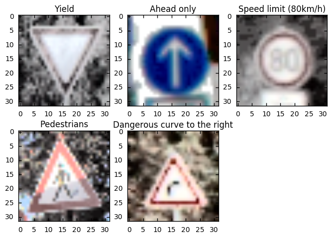

```python
#plot the 5 candidate images from the test data
candidate_labels = [13, 35, 5, 27, 20]
test_imgs = test['features']
test_labels = test['labels']
plt.style.use('seaborn-notebook')
with plt.style.context('seaborn-notebook'):
    plt.figure()
    plt.title('Random examples of the 5 candidate signs from test data')
    plt.tight_layout
    cnt = 0;
    for lbl in candidate_labels:
        #find random image for label
        cnt += 1
        indices = np.where(test_labels == lbl)
        idx = int(np.random.choice(indices[0]))
        ax = plt.subplot(2,3,cnt)
        display_image(idx, test_imgs, test_labels, plt)
```

### Question 7

*Is your model able to perform equally well on captured pictures when compared to testing on the dataset? The simplest way to do this check the accuracy of the predictions. For example, if the model predicted 1 out of 5 signs correctly, it's 20% accurate.*

```python
# Read, process and plot the 5 images downloaded from the internet corresponding to the 5 chosen candidate images
import os
files = [file_i for file_i in os.listdir("../data/internet_signs") if '.jpg' in file_i]
print(files)
```

```
['1_german_yield1.jpg', '2_german_ahead_only.jpg', '3_german_80kmh.jpg', '4_german_pedestrian.jpg', '5_german_dangerous_curve_right.jpg']
```

```python
from scipy import misc
def preprocess_test_image(img):
    img = np.reshape(img, [1,32,32,3])
    img = preprocess.hist_eq(img)
    img = preprocess.subtract_mean(img.astype(np.float32), mean_img)
    img = preprocess.min_max_scaling(img, train_min, train_max)
    return img
```

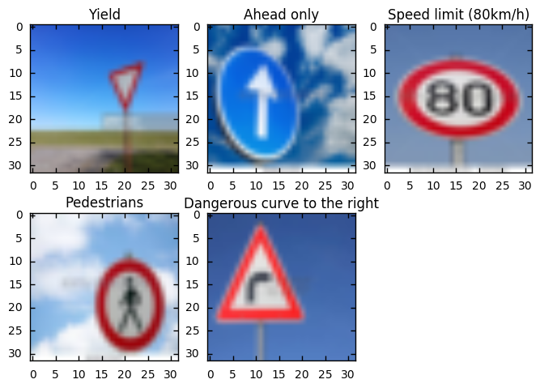

```python
# plot the 5 test images downloaded from the internet
img_list = []
sample_imgs = []
with plt.style.context('seaborn-notebook'):
    plt.figure()
    plt.tight_layout
    cnt = 0;
    for i in range(len(files)):
        cnt += 1
        img_arr = misc.imread("../data/internet_signs/" + files[i])
        img_arr = misc.imresize(img_arr, [32,32,3])
        ax = plt.subplot(2,3,cnt)
        plt.imshow(img_arr)
        sample_imgs.append(img_arr)
        plt.title(sign_names[str(candidate_labels[i])])
        img_list.append(preprocess_test_image(img_arr))
```

Note: I have intentionally chosen 'tough' images for the best performing candidates and 'easy' images for the worst performing candidates. As you can see, the yield and go ahead signs look warped and distorted while the other signs are fairly well centered. I figured given the small sample size (just 5 images), this would be a reasonable depiction of the true capabilities of the model.

```python
# Run predictions on the internet images
img_pred_labels = []
for i in img_list:
    img_pred = sess.run(pred_op, feed_dict = {X_tf: i, keep_prob: 1.0})
    img_pred_labels.append(img_pred.tolist()[0])
print("Predicted image labels", img_pred_labels)
print("Candidate image labels", candidate_labels)
```

```
Predicted image labels [39, 36, 5, 27, 20]
Candidate image labels [13, 35, 5, 27, 20]
```

The results kind of surprised me. I managed to correctly predict images corresponding to the average and worst candidates while I wrongly predicted images corresponding to the best performing candidates. So in this highly ad-hoc test, my model attained 60% accuracy (3/5).

### Question 8

*Use the model's softmax probabilities to visualize the **certainty** of its predictions, [`tf.nn.top_k`](https://www.tensorflow.org/versions/r0.12/api_docs/python/nn.html#top_k) could prove helpful here. Which predictions is the model certain of? Uncertain? If the model was incorrect in its initial prediction, does the correct prediction appear in the top k? (k should be 5 at most)*

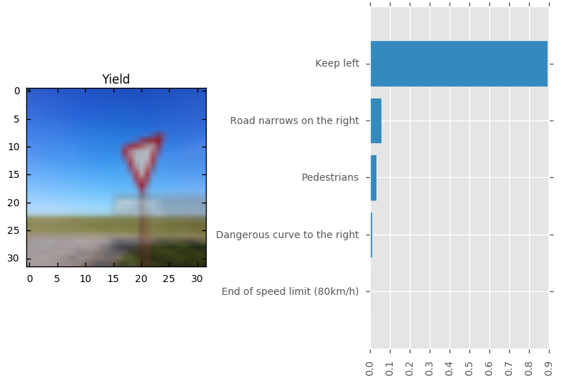

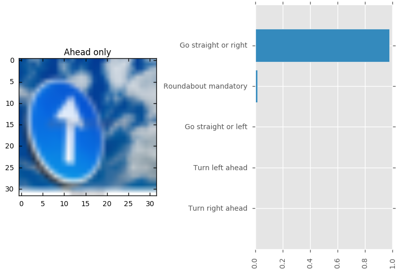

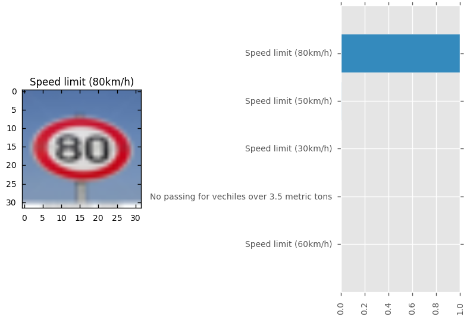

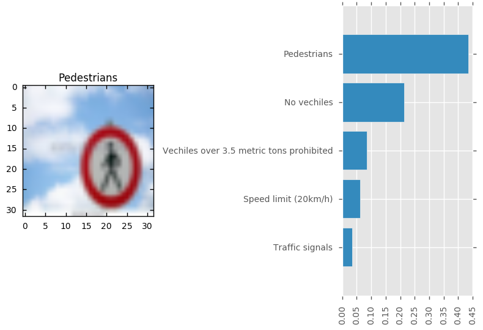

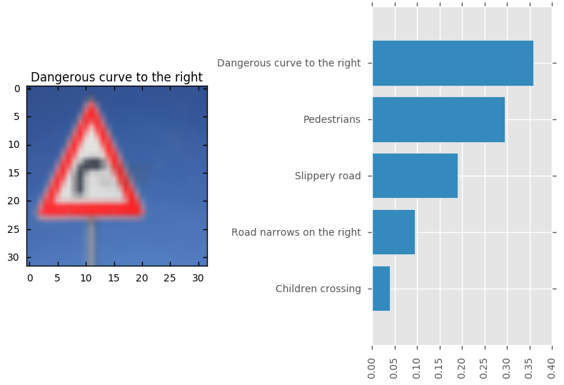

```python
smax_prob_op = tf.nn.softmax(logits)
cnt = 0;
for i in img_list:
    s_prob = sess.run(smax_prob_op, feed_dict = {X_tf: i, keep_prob: 1.0})
    top_5_prob, top_5_idx = sess.run(tf.nn.top_k(tf.constant(s_prob), k=5))
    lbl_names = [sign_names[str(i)] for i in top_5_idx[0,:]]
    with plt.style.context('seaborn-notebook'):
        plt.figure()
        ax = plt.subplot(1,2,1)
        plt.imshow(sample_imgs[cnt])
        plt.title(sign_names[str(candidate_labels[cnt])])
        #plt.tight_layout
    with plt.style.context('ggplot'):
        ax = plt.subplot(1,2,2)
        plt.barh(range(5), top_5_prob[0,:], align = 'center')
        plt.yticks(range(5), lbl_names)
        plt.xticks(rotation = 'vertical')
        plt.gca().invert_yaxis()
        plt.tight_layout()
        cnt += 1
```

Some observations:

1. The above visualizations got me surprised as well. While my model missed predicting the signs for which it supposedly had a high confidence based on the test data F1 scores ('yield' and 'ahead only'), it also got it wrong with a very high softmax probability (about 0.9)! Similarly the correctly predicted images for the worst performing candidates ('Pedestrians' and 'sharp right curve') got low softmax probability scores (about 0.4). I do not yet have a satisfying answer for this.
2. On closer inspection, the distorted 'yield sign' that I downloaded from the internet does look like a giant left arrow. This probably made the model think it is a 'keep left' sign. Also the 'ahead only' sign got classified as 'go straight or right', which is not too bad. So it is heartening to know that the model is able to make 'intelligent' guesses.
3. It seems like the model does perform really well for well centered un-distorted images while it has troubles with distorted images. This is probably not too big a deal since the real world images (probably captured from a camera mounted on a car) will not be as highly distorted as the test images I downloaded from the internet.
4. Another way the above issue can be addressed is through data augmentation. While I already apply some distortions in my augmented data, it is probably not high enough. In addition I did not distort images which already had high enough representation in the training data (the 'Yield' and 'Go Ahead' signs had more than 650 samples. So they were not augmented with affine transformations).
5. If I were asked to do one thing that would improve the model's performance even further, that would be data augmentation. Definitely smarter augmentation can boost the performance of this model. However I believe data augmentation will be a big part of the upcoming project. So I will rest this project for now.